# CS6313.002 Statistical Project 1-part 2

Shweta Rakesh Sahalot (sxs180145), Siddhi Chechani (sxc170042)

October 24, 2018

## Alternate method

Loading the token data:

```r
tokenData <- read.delim("networktenxpayTX.txt", header = FALSE, sep = " ")
tokenFrame<- as.data.frame(tokenData)
colnames(tokenFrame)<-c('fromNode','toNode','unixTime','totalAmount')
head(tokenFrame)
```

```
##   fromNode  toNode   unixTime  totalAmount
## 1      560    1452 1524611450 1.728672e+20
## 2  2011173 2011174 1524611865 4.556238e+20
## 3    75989 1822217 1524612292 5.795000e+20
## 4    40002 6382858 1524612655 4.481100e+20
## 5       17 2029263 1524612851 4.998000e+21
## 6   222770 4848204 1524612957 3.283584e+20
```

Removing Outliers from the token data:

```r
TotalSupply <-205218255.9
Decimals <- 10^18
OutlierValue <- TotalSupply*Decimals
WithoutOutlierdata <- tokenFrame[ which(tokenFrame$totalAmount < OutlierValue),]
head(WithoutOutlierdata)
```

```
##   fromNode  toNode   unixTime  totalAmount
## 1      560    1452 1524611450 1.728672e+20
## 2  2011173 2011174 1524611865 4.556238e+20
## 3    75989 1822217 1524612292 5.795000e+20
## 4    40002 6382858 1524612655 4.481100e+20
## 5       17 2029263 1524612851 4.998000e+21
## 6   222770 4848204 1524612957 3.283584e+20
```

Summary of the token data without outlier:

```r
summary(WithoutOutlierdata$totalAmount)
```

```
##      Min.   1st Qu.    Median      Mean   3rd Qu.      Max.
## 1.000e+00 5.445e+19 2.656e+20 1.844e+21 1.005e+21 7.108e+24
```

Max amount of the token data without outlier:

```r
max(WithoutOutlierdata$totalAmount)
```

```
## [1] 7.108079e+24
```

Lets check the date range for the token data

First convert the Unix time of the token data to Date format

```r
newwithoutoutlierdata <- WithoutOutlierdata
newwithoutoutlierdata$unixTime <- as.Date(as.POSIXct(WithoutOutlierdata$unixTime,origin="1970-01-01",tz="GMT"))
class(newwithoutoutlierdata$unixTime)
```

```
## [1] "Date"
```

loading the price data :

```r
priceData <- read.delim("tenxpay", header = TRUE, sep = "\t")
head(priceData)
```

```
##         Date     Open     High      Low    Close     Volume Market.Cap
## 1 07/15/2018 0.746418 0.747655 0.722171 0.730223  4,856,290 81,509,100
## 2 07/14/2018 0.698361 0.801071 0.696400 0.746002  7,753,930 76,261,300
## 3 07/13/2018 0.600009 0.844887 0.600009 0.701817 12,405,200 65,521,200
## 4 07/12/2018 0.598843 0.616721 0.568886 0.588453  4,906,510 65,393,900
## 5 07/11/2018 0.592847 0.656002 0.567525 0.599807  5,622,960 64,739,100
## 6 07/10/2018 0.629064 0.665708 0.591947 0.592098  4,754,660 68,694,000
```

```r
priceData$Date <- as.Date(priceData$Date, "%m/%d/%Y")
nrow(priceData)
```

```
## [1] 384
```

add the price return to the dataframe:

```r
priceData$Open[1]
```

```
## [1] 0.746418
```

```r
(priceData$Open[2]-priceData$Open[1])/priceData$Open[1]
```

```
## [1] -0.0643835
```

create the price return column:

```r
return <- numeric(nrow(priceData))
return[379] <- priceData$Open[379]
for (i in 378:1) {
  return[i] <- (priceData$Open[i]-priceData$Open[i+1])/priceData$Open[i+1]
}
return[2]
```

```
## [1] 0.1639175
```

```r
return
```

```
##   [1]  0.068813980  0.163917541  0.001947088  0.010113908 -0.057572838
##   [6] -0.022667458 -0.017043008  0.037745029 -0.078915831 -0.023267054
##  [11] -0.038467971 -0.066616848  0.061265590 -0.043285639  0.041549616
##  [16]  0.405611444  0.045854751  0.033958197 -0.065093445  0.001849437
##  [21] -0.004377022 -0.012588872 -0.121068156 -0.022758107 -0.028354658
##  [26]  0.008215009  0.018451945  0.010484659 -0.009340419 -0.033928047
##  [31]  0.057882651 -0.084831760 -0.138437066  0.049033261 -0.134656730
##  [36] -0.053444088 -0.008566712  0.001699272 -0.014321205  0.016852473
##  [41] -0.068688407  0.021114237  0.029949275 -0.019852877  0.028216621
##  [46] -0.014066779  0.050288032 -0.086291661 -0.026592122  0.005148938
##  [51] -0.011660375  0.023407089 -0.105367593 -0.092436975 -0.055555556
##  [56]  0.000000000 -0.038167939  0.023437500 -0.104895105  0.091603053
##  [61]  0.007692308  0.040000000  0.077586207  0.017543860 -0.102362205
##  [66] -0.059259259 -0.014598540 -0.028368794 -0.007042254 -0.089743590
##  [71] -0.042944785  0.012422360 -0.018292683  0.018633540  0.025477707
```

[output cut: 62 more lines]

adding the price return column to the pricedata dataframe

```r
priceData$return <- return
priceData$return[378]
```

```
## [1] -0.1317901
```

```r
head(newwithoutoutlierdata$Date)
```

[output not shown]

```r
colnames(newwithoutoutlierdata)<-c('fromNode','toNode','Date','totalAmount')
newwithoutoutlierdata$Date[4]
```

```
## [1] "2018-04-24"
```

```r
class(priceData$Date)
```

```
## [1] "Date"
```

merge both the dataframes according to dates

```r
newdataset <- merge(newwithoutoutlierdata,priceData,by = "Date")
head(newdataset$Date)
```

```
## [1] "2017-06-27" "2017-06-27" "2017-06-27" "2017-06-27" "2017-06-27"
## [6] "2017-06-27"
```

Creating a feature of no of transactions from the data for doing simple linear regression.

```r
frequencytrans <- table(newdataset$Date)
freqtrans<- as.data.frame(frequencytrans)
summary(freqtrans)
```

```
##          Var1          Freq
##  2017-06-27:  1   Min.   :   9.0
##  2017-06-28:  1   1st Qu.: 357.2
##  2017-06-29:  1   Median : 790.0
##  2017-06-30:  1   Mean   :1049.8
##  2017-07-01:  1   3rd Qu.:1272.2
##  2017-07-02:  1   Max.   :7088.0
##  (Other)   :308
```

```r
colnames(freqtrans) <- c("Date","no_of_trans")
freqtrans$Date <- as.Date(freqtrans$Date)
```

mergeing freq trans with newdataset

```r
newsimpletable <- merge(priceData,freqtrans,by = "Date")
head(newsimpletable$return)
```

```
## [1]  0.0  0.0  0.0  0.0  0.0 32.4
```

```r
newsimpletable<- newsimpletable[,c(-2:-7)]
head(newsimpletable$no_of_trans)
```

```
## [1] 25 13 15 10 12 15
```

Data Preparation:

```r
summary(newsimpletable)
```

```
##       Date                return          no_of_trans
##  Min.   :2017-06-27   Min.   :-0.98481   Min.   :   9.0
##  1st Qu.:2017-09-13   1st Qu.:-0.05329   1st Qu.: 357.2
##  Median :2017-11-30   Median : 0.00000   Median : 790.0
##  Mean   :2017-11-30   Mean   : 0.10975   Mean   :1049.8
##  3rd Qu.:2018-02-16   3rd Qu.: 0.06177   3rd Qu.:1272.2
##  Max.   :2018-05-06   Max.   :32.40000   Max.   :7088.0
```

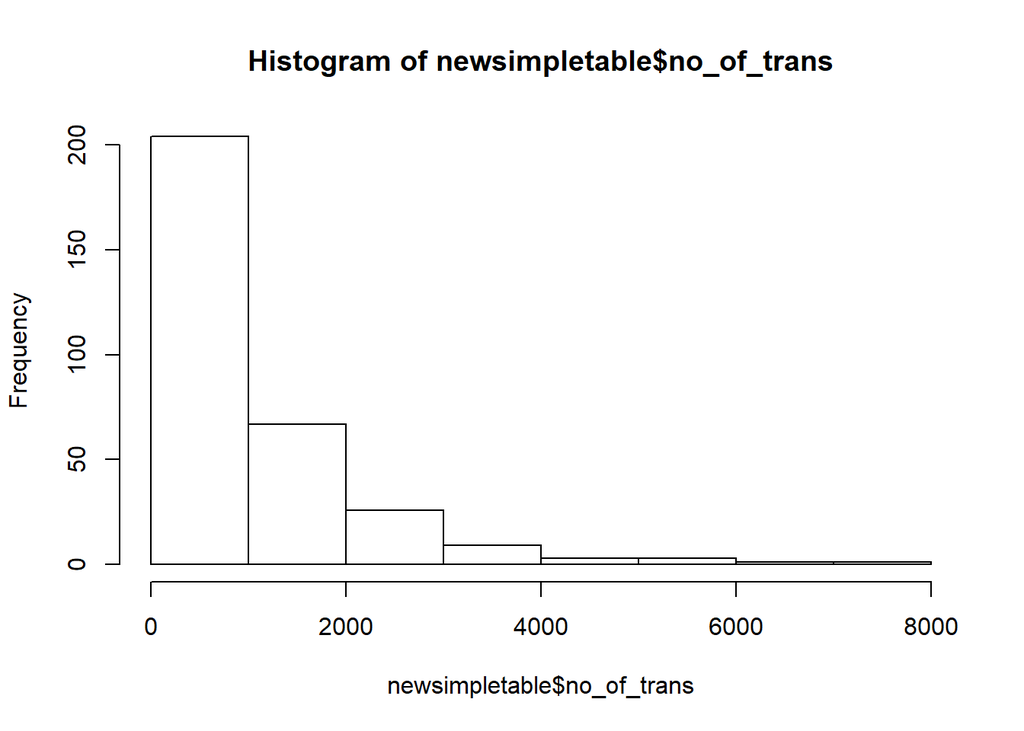

```r
hist(newsimpletable$no_of_trans)
```

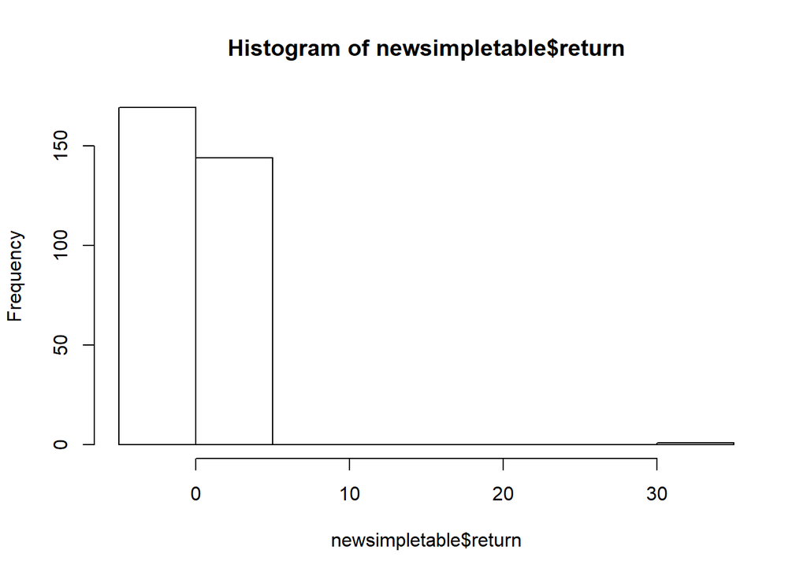

```r
hist(newsimpletable$return)
```

Analysis:

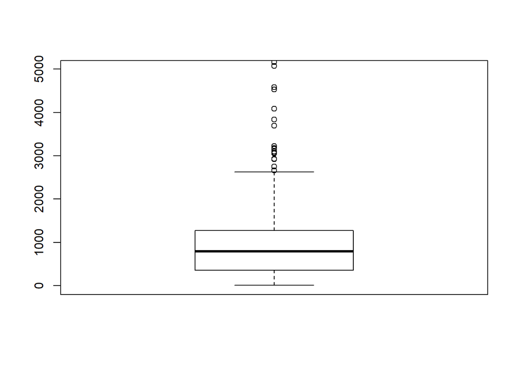

```r
par(mfrow = c(1,1))
bx = boxplot(newsimpletable$no_of_trans,ylim = c(0,5000))
```

checking the distribution of no of transactions:

```r
quantile(newsimpletable$no_of_trans, seq(0,1,0.02))
```

```
##      0%      2%      4%      6%      8%     10%     12%     14%     16%
##    9.00   15.00  139.12  168.80  201.00  219.30  225.36  239.82  253.24
##     18%     20%     22%     24%     26%     28%     30%     32%     34%
##  268.02  288.40  300.16  318.16  385.04  403.84  429.70  470.92  543.56
##     36%     38%     40%     42%     44%     46%     48%     50%     52%
##  586.76  629.00  674.00  702.00  736.16  749.98  764.24  790.00  805.28
##     54%     56%     58%     60%     62%     64%     66%     68%     70%
##  823.02  846.68  868.32  904.00  940.66  968.64 1023.16 1080.84 1134.20
##     72%     74%     76%     78%     80%     82%     84%     86%     88%
## 1166.40 1250.10 1323.80 1430.48 1549.20 1647.18 1812.72 1938.72 2073.76
##     90%     92%     94%     96%     98%    100%
## 2204.00 2461.08 2787.52 3164.68 4416.56 7088.00
```

boxplot stats:

```r
bx$stats
```

```
##      [,1]
## [1,]    9
## [2,]  356
## [3,]  790
## [4,] 1275
## [5,] 2628
## attr(,"class")
##
## "integer"
```

```r
summary(newsimpletable$no_of_trans)
```

```
##    Min. 1st Qu.  Median    Mean 3rd Qu.    Max.
##     9.0   357.2   790.0  1049.8  1272.2  7088.0
```

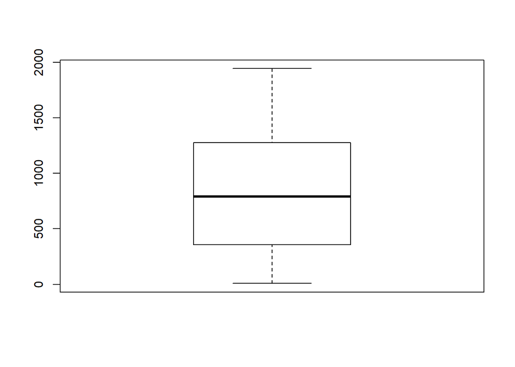

```r
newsimpletable$no_of_trans<-ifelse(newsimpletable$no_of_trans>2000,1500,newsimpletable$no_of_trans)
boxplot(newsimpletable$no_of_trans)
```

checking the response variable:

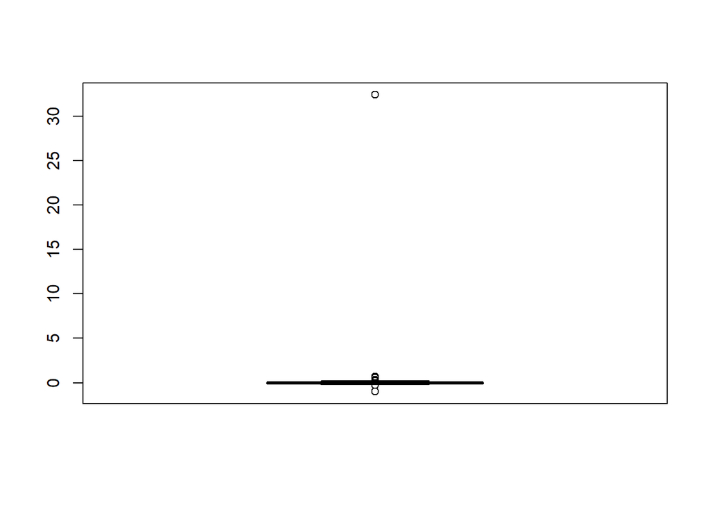

```r
boxplot(newsimpletable$return)
```

bivariate analysis:

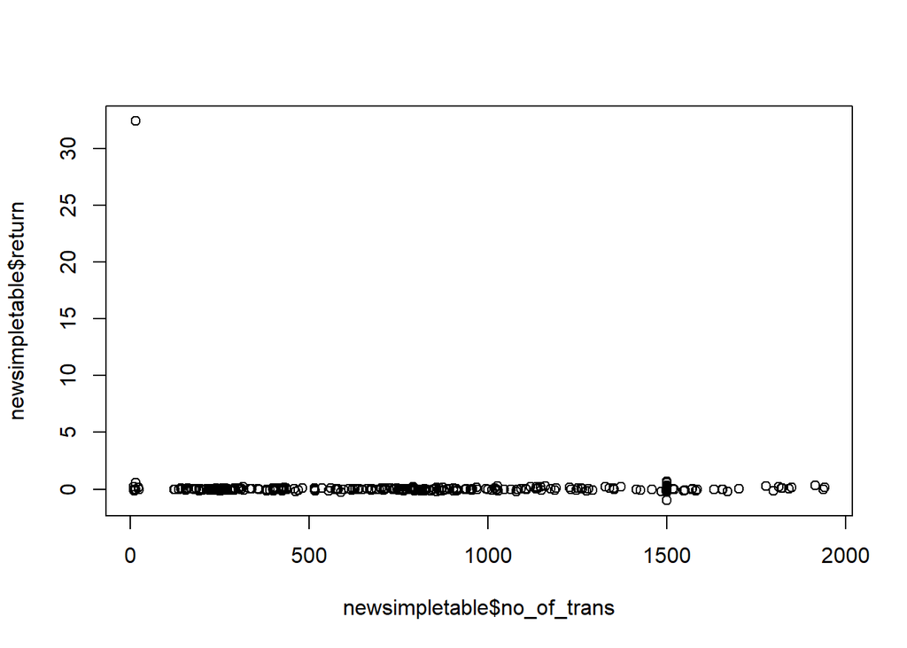

```r
plot(newsimpletable$no_of_trans,newsimpletable$return)
```

lets check the correlation:

```r
cor(newsimpletable[,c(2,3)])
```

```
##                  return no_of_trans
## return       1.00000000 -0.08815697
## no_of_trans -0.08815697  1.00000000
```

fitting the linear model:

```r
library(fmsb)
final_data <- lm(return~no_of_trans,data=newsimpletable)
VIF(final_data)
```

```
## [1] 1.007833
```

```r
summary(final_data)
```

```
##
## Call:
## lm(formula = return ~ no_of_trans, data = newsimpletable)
##
## Residuals:
##    Min     1Q Median     3Q    Max
## -0.882 -0.260 -0.128  0.028 32.031
##
## Coefficients:
##               Estimate Std. Error t value Pr(>|t|)
## (Intercept)  0.3735991  0.1978206   1.889   0.0599 .
## no_of_trans -0.0003173  0.0002030  -1.563   0.1190
## ---
## Signif. codes:  0 '***' 0.001 '**' 0.01 '*' 0.05 '.' 0.1 ' ' 1
##
## Residual standard error: 1.828 on 312 degrees of freedom
## Multiple R-squared:  0.007772,   Adjusted R-squared:  0.004591
## F-statistic: 2.444 on 1 and 312 DF,  p-value: 0.119
```

```r
library(lmtest)
```

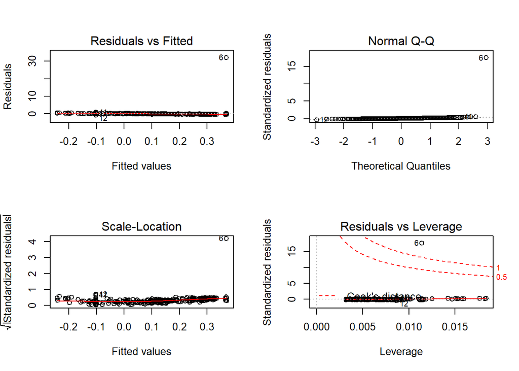

```r
par(mfrow = c(2,2))
plot(final_data)
```

now trying by taking the sqaureroot of the predictor variable:

```r
newsimpletable$no_of_trans <- (newsimpletable$no_of_trans)^(0.5)
final_data <- lm(return~no_of_trans,data=newsimpletable)
VIF(final_data)
```

```
## [1] 1.018227
```

```r
summary(final_data)
```

```
##
## Call:
## lm(formula = return ~ no_of_trans, data = newsimpletable)
##
## Residuals:
##    Min     1Q Median     3Q    Max
## -0.835 -0.319 -0.101  0.090 31.707
##
## Coefficients:
##             Estimate Std. Error t value Pr(>|t|)
## (Intercept)  0.79052    0.30337   2.606  0.00961 **
## no_of_trans -0.02509    0.01052  -2.385  0.01769 *
## ---
## Signif. codes:  0 '***' 0.001 '**' 0.01 '*' 0.05 '.' 0.1 ' ' 1
##
## Residual standard error: 1.819 on 312 degrees of freedom
## Multiple R-squared:  0.0179, Adjusted R-squared:  0.01475
## F-statistic: 5.687 on 1 and 312 DF,  p-value: 0.01769
```

creating 2 new features no of tokens and no of buys:

so first dividing the total amount of the dataset with 10^8 to find the no of tokens and then grouping it and adding it acording to the date

```r
newdataset$totalAmount <- (newdataset$totalAmount/(10^8))
tokentable <- aggregate(newdataset$totalAmount, by = list(Category = newdataset$Date), FUN = sum)
head(tokentable)
```

```
##     Category            x
## 1 2017-06-27 1.409702e+14
## 2 2017-06-28 3.119692e+15
## 3 2017-06-29 2.003250e+14
## 4 2017-06-30 3.125740e+14
## 5 2017-07-01 1.575796e+14
## 6 2017-07-02 4.625641e+14
```

```r
colnames(tokentable)<- c("Date","total_token")
newsimpletable <- merge(newsimpletable,tokentable,by = "Date")
class(newdataset$Date)
```

```
## [1] "Date"
```

```r
buyerstable <- aggregate(data=newdataset, toNode ~ Date, function(x) length(unique(x)))
head(buyerstable)
```

```
##         Date toNode
## 1 2017-06-27     21
## 2 2017-06-28     11
## 3 2017-06-29     10
## 4 2017-06-30      7
## 5 2017-07-01     11
## 6 2017-07-02     10
```

```r
summary(buyerstable)
```

```
##       Date                toNode
##  Min.   :2017-06-27   Min.   :   7.0
##  1st Qu.:2017-09-13   1st Qu.: 234.0
##  Median :2017-11-30   Median : 532.0
##  Mean   :2017-11-30   Mean   : 658.4
##  3rd Qu.:2018-02-16   3rd Qu.: 810.0
##  Max.   :2018-05-06   Max.   :4708.0
```

```r
colnames(buyerstable) <- c("Date","unique_buyers")
newsimpletable  <- merge(newsimpletable,buyerstable,by = "Date")
```

time for data preparation:

```r
summary(newsimpletable)
```

```
##       Date                return          no_of_trans
##  Min.   :2017-06-27   Min.   :-0.98481   Min.   : 3.00
##  1st Qu.:2017-09-13   1st Qu.:-0.05329   1st Qu.:18.90
##  Median :2017-11-30   Median : 0.00000   Median :28.11
##  Mean   :2017-11-30   Mean   : 0.10975   Mean   :27.14
##  3rd Qu.:2018-02-16   3rd Qu.: 0.06177   3rd Qu.:35.67
##  Max.   :2018-05-06   Max.   :32.40000   Max.   :44.07
##   total_token        unique_buyers
##  Min.   :1.410e+14   Min.   :   7.0
##  1st Qu.:4.955e+15   1st Qu.: 234.0
##  Median :7.916e+15   Median : 532.0
##  Mean   :1.935e+16   Mean   : 658.4
##  3rd Qu.:1.854e+16   3rd Qu.: 810.0
##  Max.   :5.225e+17   Max.   :4708.0
```

then lets do univariate analysis on all independent variables

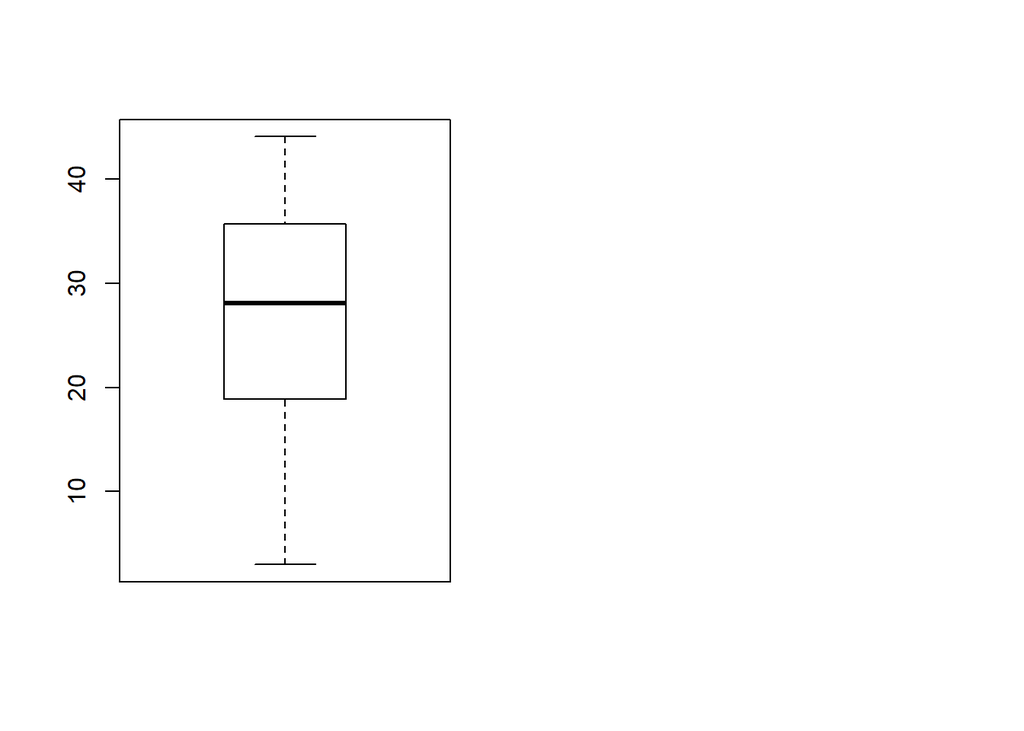

```r
par(mfrow=c(1,2))
bx = boxplot(newsimpletable$no_of_trans)
```

capping the outliers:

```r
# quantile(newsimpletable$no_of_trans, seq(0,1,0.02))
# newsimpletable$no_of_trans<-ifelse(newsimpletable$no_of_trans>60,59,newsimpletable$no_of_trans)
# boxplot(newsimpletable$no_of_trans)
```

checking unique buyers:

```r
par(mfrow=c(1,2))
bx = boxplot(newsimpletable$unique_buyers)
quantile(newsimpletable$unique_buyers, seq(0,1,0.02))
```

```
##      0%      2%      4%      6%      8%     10%     12%     14%     16%
##    7.00   11.26  115.52  135.34  155.00  164.50  174.00  180.28  190.16
##     18%     20%     22%     24%     26%     28%     30%     32%     34%
##  199.34  211.60  218.72  230.00  239.00  253.64  275.60  302.96  322.26
##     36%     38%     40%     42%     44%     46%     48%     50%     52%
##  353.04  388.62  415.20  444.84  475.88  489.94  517.44  532.00  559.32
##     54%     56%     58%     60%     62%     64%     66%     68%     70%
##  579.04  589.12  605.08  624.00  652.78  677.64  686.90  704.00  734.50
##     72%     74%     76%     78%     80%     82%     84%     86%     88%
##  768.00  787.62  856.44  886.50  955.60 1030.30 1108.56 1174.08 1214.44
##     90%     92%     94%     96%     98%    100%
## 1331.50 1401.96 1551.12 1889.12 2467.54 4708.00
```

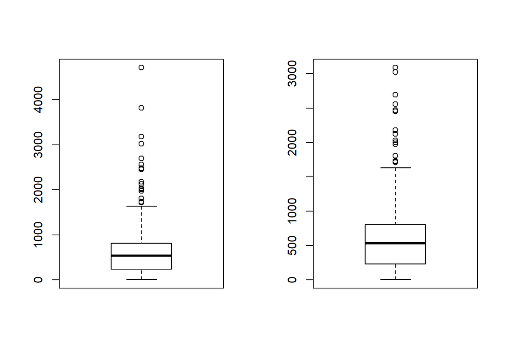

```r
newsimpletable$unique_buyers<-ifelse(newsimpletable$unique_buyers>3087,3088,newsimpletable$unique_buyers)
boxplot(newsimpletable$unique_buyers)
```

checking for no of tokens:

```r
par(mfrow=c(1,2))
bx = boxplot(newsimpletable$total_token)
quantile(newsimpletable$total_token, seq(0,1,0.02))
```

```
##           0%           2%           4%           6%           8%
## 1.409702e+14 4.536653e+14 1.471612e+15 2.110669e+15 2.551931e+15
##          10%          12%          14%          16%          18%
## 3.116653e+15 3.456227e+15 3.748938e+15 4.016769e+15 4.224678e+15
##          20%          22%          24%          26%          28%
## 4.374631e+15 4.646226e+15 4.904279e+15 5.058124e+15 5.232375e+15
##          30%          32%          34%          36%          38%
## 5.460118e+15 5.621495e+15 5.875627e+15 6.158514e+15 6.320170e+15
##          40%          42%          44%          46%          48%
## 6.533721e+15 6.761005e+15 7.071005e+15 7.222123e+15 7.506538e+15
##          50%          52%          54%          56%          58%
## 7.915912e+15 8.456711e+15 8.757019e+15 9.169928e+15 9.785257e+15
##          60%          62%          64%          66%          68%
## 1.001398e+16 1.030422e+16 1.077617e+16 1.149179e+16 1.283490e+16
##          70%          72%          74%          76%          78%
## 1.360846e+16 1.493365e+16 1.811259e+16 1.944754e+16 2.147736e+16
##          80%          82%          84%          86%          88%
## 2.259460e+16 2.812904e+16 3.055752e+16 3.345500e+16 3.943318e+16
##          90%          92%          94%          96%          98%
## 4.429327e+16 4.860446e+16 5.921017e+16 7.865907e+16 1.176165e+17
##         100%
## 5.225067e+17
```

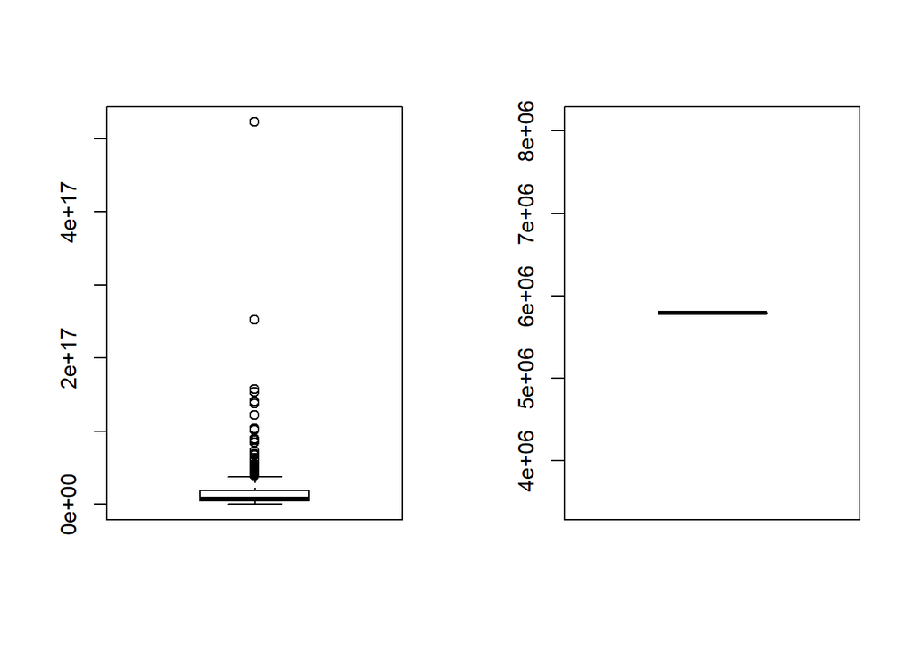

```r
newsimpletable$total_token<-ifelse(newsimpletable$total_token>5791001,5791001,newsimpletable$total_token)
boxplot(newsimpletable$total_token)
```

lets check the response variable:

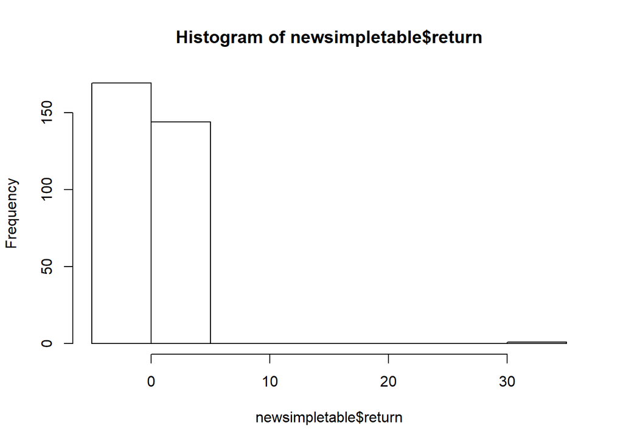

```r
hist(newsimpletable$return)
```

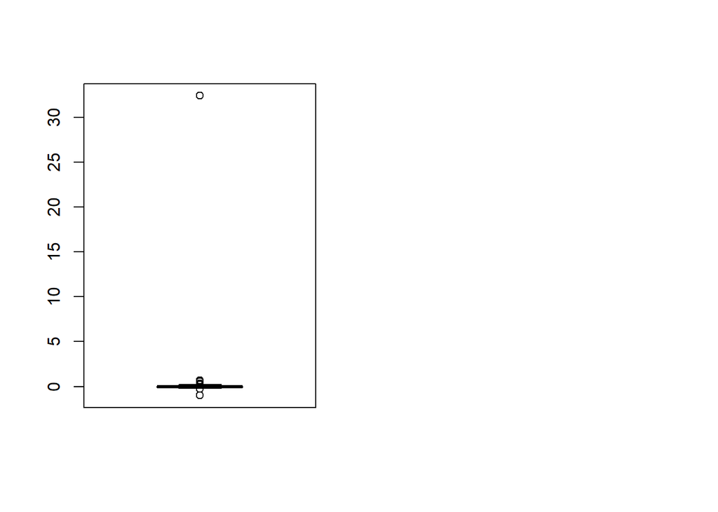

```r
par(mfrow=c(1,2))
bx = boxplot(newsimpletable$return)
```

bivariate analysis:

square root number of transactions vs return:

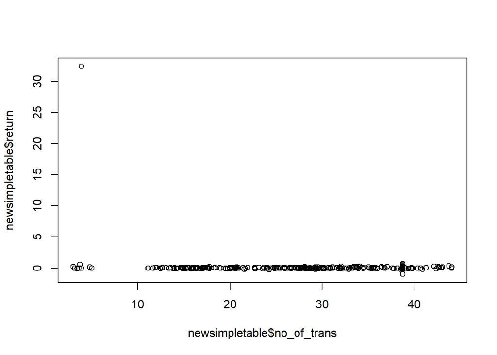

```r
plot(newsimpletable$no_of_trans,newsimpletable$return)
```

lets check for total token vs return:

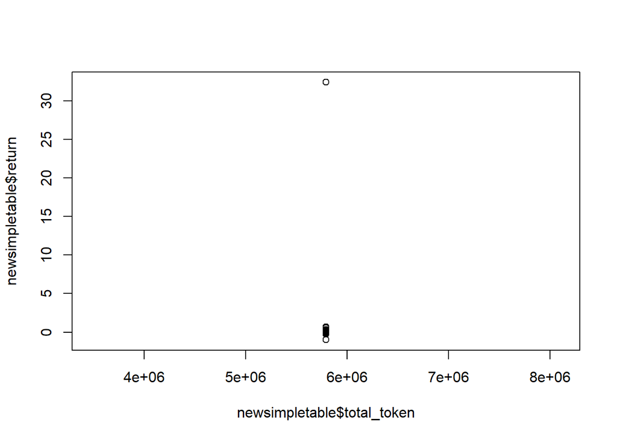

```r
plot(newsimpletable$total_token,newsimpletable$return)
```

lets check unique buyers vs return:

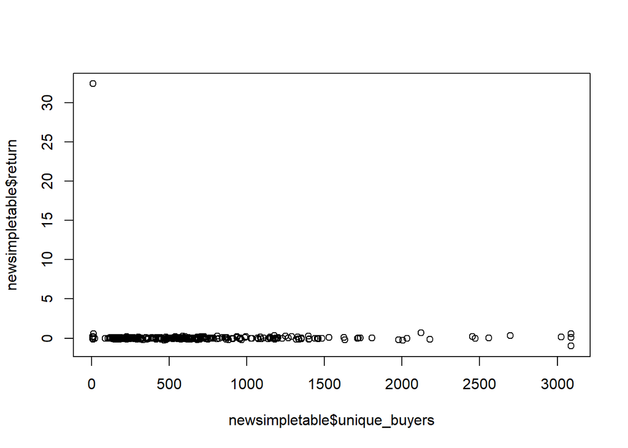

```r
plot(newsimpletable$unique_buyers,newsimpletable$return)
```

lets check the correlation:

```r
cor(newsimpletable[,c(2:5)])
```

```
##                    return no_of_trans total_token unique_buyers
## return         1.00000000  -0.1337920          NA   -0.06212329
## no_of_trans   -0.13379200   1.0000000          NA    0.75555525
## total_token            NA          NA           1            NA
## unique_buyers -0.06212329   0.7555553          NA    1.00000000
```

```r
library(dplyr)
summary(newdataset)
```

```
##       Date               fromNode           toNode
##  Min.   :2017-06-27   Min.   :      5   Min.   :      5
##  1st Qu.:2017-08-15   1st Qu.:     17   1st Qu.: 431538
##  Median :2017-09-17   Median : 297031   Median :2062611
##  Mean   :2017-10-16   Mean   :1644441   Mean   :3179799
##  3rd Qu.:2017-12-15   3rd Qu.:1943406   3rd Qu.:6393477
##  Max.   :2018-05-06   Max.   :6438429   Max.   :6438432
##
##   totalAmount             Open              High              Low
##  Min.   :0.000e+00   Min.   : 0.5685   Min.   : 0.6111   Min.   : 0.4787
##  1st Qu.:5.445e+11   1st Qu.: 1.7300   1st Qu.: 1.9500   1st Qu.: 1.5800
##  Median :2.658e+12   Median : 2.3200   Median : 2.4900   Median : 2.0300
##  Mean   :1.844e+13   Mean   : 3.6169   Mean   : 3.9031   Mean   : 2.2656
##  3rd Qu.:1.005e+13   3rd Qu.: 3.6000   3rd Qu.: 3.8600   3rd Qu.: 3.1600
##  Max.   :7.108e+16   Max.   :73.0600   Max.   :86.2600   Max.   :49.0500
##
##      Close                Volume             Market.Cap
##  Min.   : 0.570   144,769,000:  7088   -          :  9809
##  1st Qu.: 1.740   11,828,700 :  6226   471,783,000:  7088
##  Median : 2.220   20,158,400 :  5945   333,047,000:  6226
##  Mean   : 2.545   72,243,200 :  5161   131,122,000:  5945
##  3rd Qu.: 3.590   17,115,200 :  5073   300,417,000:  5161
##  Max.   :63.830   9,172,650  :  4588   224,227,000:  4532
##                   (Other)    :295556   (Other)    :290876
##      return
##  Min.   :-0.98481
##  1st Qu.:-0.06126
##  Median : 0.00000
##  Mean   : 0.02160
##  3rd Qu.: 0.07759
##  Max.   :32.40000
##
```

```r
investortable <- newdataset %>% group_by(Date)
totalinvestor_table<- summarize(investortable , total_investors = n_distinct(toNode))
head(totalinvestor_table)
```

```
## # A tibble: 6 x 2
##   Date       total_investors
##   <date>               <int>
## 1 2017-06-27              21
## 2 2017-06-28              11
## 3 2017-06-29              10
## 4 2017-06-30               7
## 5 2017-07-01              11
## 6 2017-07-02              10
```

```r
newinvestortable <- newdataset %>% group_by(Date,toNode)
newinvestortable_totaltoken <- summarise(newinvestortable,total_token = sum(totalAmount))
summary(newinvestortable_totaltoken)
```

```
##       Date                toNode         total_token
##  Min.   :2017-06-27   Min.   :      5   Min.   :0.000e+00
##  1st Qu.:2017-08-21   1st Qu.: 460418   1st Qu.:6.031e+11
##  Median :2017-09-26   Median :3571979   Median :2.500e+12
##  Mean   :2017-10-18   Mean   :3617180   Mean   :2.940e+13
##  3rd Qu.:2017-12-15   3rd Qu.:6400372   3rd Qu.:1.000e+13
##  Max.   :2018-05-06   Max.   :6438432   Max.   :7.108e+16
```

```r
subsetnewinvestortable_totaltoken <- newinvestortable_totaltoken[ which(newinvestortable_totaltoken$total_token>100), ]
finalinvestortable <- summarise(subsetnewinvestortable_totaltoken, final_investors = n_distinct(toNode))
newfinalinvestortable <- merge(totalinvestor_table,finalinvestortable,by = "Date")
newfinalinvestortable$percentage_investors <- (newfinalinvestortable$final_investors/newfinalinvestortable$total_investors)*100
newsimpletable <- merge(newsimpletable,newfinalinvestortable,by = "Date")
```

writiting the previous day fix :

```r
head(newsimpletable$Date)
```

```
## [1] "2017-06-27" "2017-06-28" "2017-06-29" "2017-06-30" "2017-07-01"
## [6] "2017-07-02"
```

```r
tail(newsimpletable$return)
```

```
## [1]  0.04666667  0.02547771  0.01863354 -0.01829268  0.01242236 -0.04294479
```

```r
shift <- function(x, n){
  c(x[-(seq(n))], rep(NA, n))
}
newsimpletable$return <- shift(newsimpletable$return, 1)
newsimpletable <- newsimpletable[1:(nrow(newsimpletable)-1),]
```